# Course Project

EFon

```r
#install.packages("tidyverse")
```

The tidyverse packages will be used for most of this analysis. Install now or load from library.

```r
library(tidyverse)
library(lubridate)
library(lattice)
#getwd()
```

# Code for reading in the dataset and/or processing the data

The website address is saved and we use code to download directly to working directory. File is in zip format so unzip is necessary. The data are loaded into R using the read.csv package.

```r
fileURL <- "https://d396qusza40orc.cloudfront.net/repdata%2Fdata%2Factivity.zip"

download.file(fileURL, destfile = "nikedata.zip")

unzip("nikedata.zip")

nike <- read.csv("activity.csv")

# view(head(nike)) This code shows top chunk of data if required.
```

# Histogram of the total number of steps taken each day

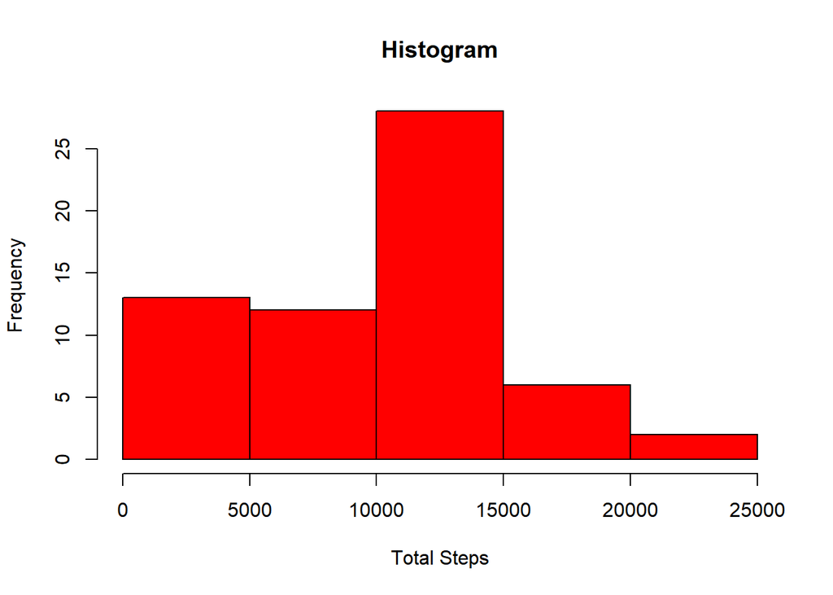

```r
par(mfrow = c(1,1)) # Set the appropriate margins for graphing

nike[["date"]] <- as_date(nike[["date"]], ymd()) #convert date column to as.date format for easy processing.

daynike <- nike %>% group_by(date) %>% summarise(Totsteps = sum(steps, na.rm = TRUE))
 # Using the nike dataset, group by date then calculate the total number of steps for each day.


hist(daynike$Totsteps,col = "red", xlab = "Total Steps", main = "Histogram")
```

```r
# A histogram of our results.
```

# Mean and median number of steps taken each day

```r
mean(daynike$Totsteps, na.rm = TRUE)
```

```
## [1] 9354.23
```

```r
median(daynike$Totsteps, na.rm = TRUE)
```

```
## [1] 10395
```

# Time series plot of the average number of steps taken

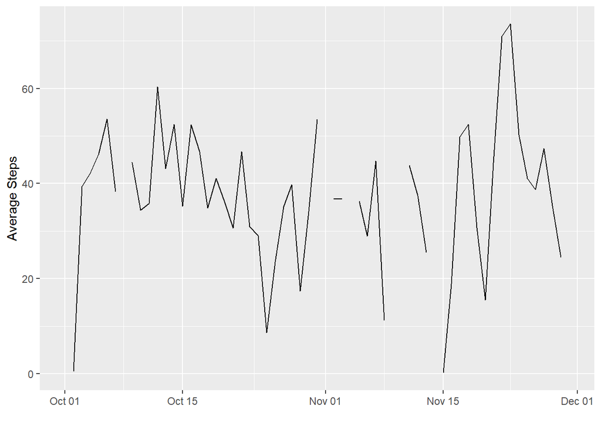

```r
meanSTEPS <- nike %>% group_by(date) %>% summarise(avg = mean(steps, na.rm = TRUE)) # Average number of steps

qplot(data = meanSTEPS, x = date, y = avg, geom = "path", ylab = "Average Steps", xlab = " ")
```

# The 5-minute interval that, on average, contains the maximum number of steps

```r
 intnike <- nike %>% group_by(interval) %>% summarise(avg = mean(steps, na.rm = TRUE))
 # view(intnike)


 max(intnike$avg, na.rm = TRUE) #Here we find the max value first, then use it to filter row that matches.
```

```
## [1] 206.1698
```

```r
 # 206.1698

 maxinterval <- intnike %>% filter(avg == max(intnike$avg, na.rm = TRUE)) #filter rows that match max steps.

 view(maxinterval)
```

[output not shown]

# Calculate and report the total number of missing values in the dataset(NAs)

```r
sum(is.na(nike))
```

```
## [1] 2304
```

# Code to describe and show a strategy for imputing missing data

Devise a strategy for filling in all of the missing values in the dataset. The strategy does not need to be sophisticated. For example, you could use the mean/median for that day, or the mean for that 5-minute interval, etc. Create a new dataset that is equal to the original dataset but with the missing data filled in (cleannike). Make a histogram of the total number of steps taken each day and calculate and report the mean and median total number of steps taken per day. Do these values differ from the estimates from the first part of the assignment? What is the impact of imputing missing data on the estimates of the total daily number of steps?

We compute the 5-minute interval means(Intvmean) and use those to replace missing values.

```r
Intvmean <- nike %>% group_by(interval) %>% summarise(meanSTEPS = mean(steps, na.rm = TRUE)) # group by interval and get the mean number of steps for each interval.


cleannike <- nike %>% group_by(date, interval)



cleannike$steps[is.na(cleannike$steps)] <- Intvmean$meanSTEPS
# For any rows in cleannike that contain NA, replace these with the mean number of steps for each interval.

#We have obtained a new clean dataset without missing values. We confirm below, should have zero NAs.

sum(is.na(cleannike))
```

```
## [1] 0
```

# Histogram of the total number of steps taken each day after missing values are imputed

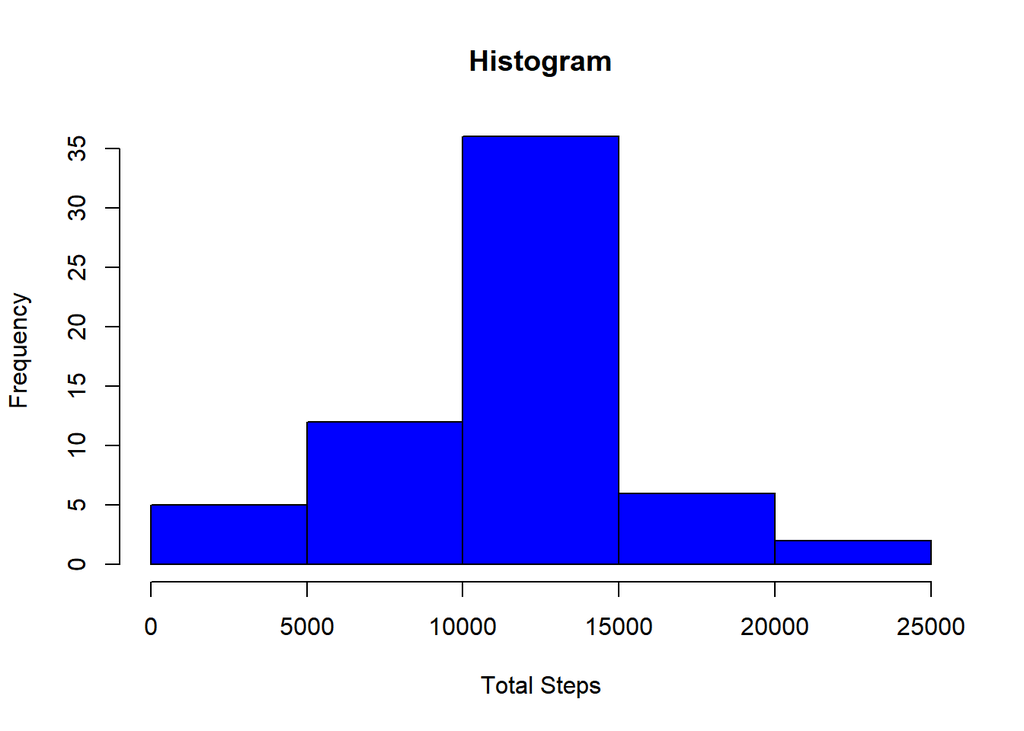

```r
nikenew <- cleannike %>% group_by(date) %>% summarise(Totalstp = sum(steps))

hist(nikenew$Totalstp, col = "blue", xlab = "Total Steps", main = "Histogram")
```

# Calculate and report the mean and median total number of steps taken per day.

```r
mean(nikenew$Totalstp)
```

```
## [1] 10766.19
```

```r
median(nikenew$Totalstp)
```

```
## [1] 10766.19
```

# Panel plot comparing the average number of steps taken per 5-minute interval across weekdays and weekends

First, we must convert our dates to weekdays such as Monday, Tuesday, etc. Then we split them into two groups for the different types; Weekdays and Weekends.

```r
nikeweeks <- cleannike %>% ungroup() %>% mutate(weekdays = weekdays(as_date(cleannike[["date"]])))


nikewk_type <- nikeweeks %>% mutate(weektype = ifelse(nikeweeks$weekdays %in% c("Saturday", "Sunday"), "WkEnd", "WDay"))

table(nikewk_type$weektype)
```

```
##
##  WDay WkEnd
## 12960  4608
```

# PLOT

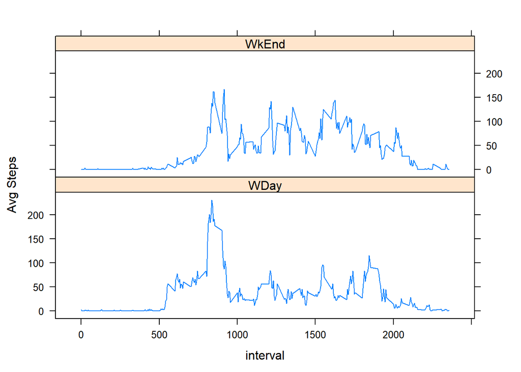

```r
cobo <- nikewk_type %>% group_by(interval, weektype) %>% summarise(menot = mean(steps))

xyplot(menot ~ interval | weektype, data=cobo, type="l", ylab = "Avg Steps", layout=c(1,2))
```